# Virginia Math Bulletin

- Faculty News
- Department News
- Graduate News

Issue 4 Volume 1 June 2017

## View from the Chair

Craig Huneke  
Marvin Rosenblum Professor of Mathematics

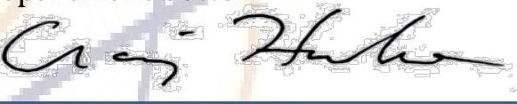

This is the last summer of my term as Chair, and it is the last time I will be writing this column. Over the last several years, the Mathematics Department changed enormously. Even as universities across the country face significant challenges, both economic and social, our department has thrived. There are still many challenges that remain for both UVa and our department, but we are well-positioned to continue our progress. We have outstanding colleagues taking over as Chair. Zoran Grujic will serve as Interim Chair for one year, after which John Imbrie becomes Chair. John is on sabbatical next year at Princeton.

We were delighted to welcome five new tenure-track and tenured faculty last Fall: Julie Bergner, Francesco Di Plinio, Juraj Földes, Sara Maloni, and Jennifer Morse. We also welcomed two new postdocs, Axel Saenz-Rodriguez and Ramanujan Santharoubane. Please read about their work in the following pages. Since I’ve been at UVa we have hired twelve outstanding new faculty, who infuse the department with energy and new ideas. During this time we have also begun a significant transformation of the way we teach Calculus, moving to an inquiry-based learning model crafted for our own students. Paul Bourdon has headed up this change, and you will hear more about it in later newsletters.

In this issue we have a special article on the recent work of John Imbrie on the many-body localization problem in mathematical physics. His work has attracted considerable attention this last year. I hope you enjoy reading it as much as I did.

We were saddened by the passing this year of Emeritus Professor Gene Paige, whom I was lucky to get to know during my time here. He always brought good cheer and a calm demeanor to the department, and will be greatly missed. Don Ramirez announced his retirement after 50 years of teaching and research at UVa. Don’s institutional memory and stories about the department’s history will be irreplaceable. You can read more about Gene and Don in the newsletter.

The department continues to have many research visitors and activities, some centered on our Institute of Mathematics and the Virginia Math Lectures Series. We had two workshops during the year. The Seminar on Stochastic Processes (SSP) is a fixture in the probability community and the most important regular conference series for probabilists in North America. The 37th Seminar on Stochastic Processes was hosted at University of Virginia, 8-11 March 2017. In connection with our Virginia Mathematics Lecture by Benedict Gross which you can read about in this newsletter, we hosted a workshop “Elliptic Curves, Torsors and $L$-functions”.

I have been grateful for the support of our wonderful faculty, staff, students, our Dean’s office, our alumni, and our friends during my time as Chair. One of the greatest benefits of being Chair has been the pleasure of working with a great number of people committed to making our department better.

## Supporting Us

The Mathematics Department is grateful for the generous support of its alumni and friends. The Department welcomes gifts annually to address its most urgent needs, as well as to the endowment which provides funding in perpetuity. To learn about how you can make a difference by supporting the Mathematics Department, please contact Liz Blaine at lblaine@virginia.edu or (434) 924-6156. To make a gift online, please visit http://giving.virginia.edu/mathematics

## New Faculty Profiles

### Julie Bergner

Associate Professor  
Department of Mathematics

Supported by a National Science Foundation CAREER grant, Julie Bergner focuses her research in the area of homotopy

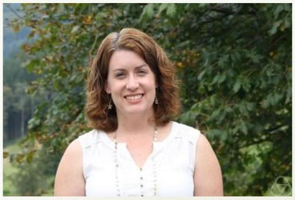

theory, in which mathematical objects are considered up to deformation and are hence more flexible. Much of her work has been concerned with having a good framework for looking at algebraic and categorical structures from this perspective. In her current projects, Bergner is using these ideas to make connections between fields as diverse as topology, representation theory, mathematical physics and algebraic geometry.

Before joining the Arts & Sciences faculty, Bergner was a research visitor at the Mathematical Sciences Research Institute (MSRI) in Berkeley, Calif. She also has been a research fellow at the Hausdorff Research Institute for Mathematics and the Max Planck Institute for Mathematics (both in Bonn, Germany), as well as at the Centre de Recerca Matemàtica in Barcelona, Spain.

Bergner’s publications include a recent paper in Geometry and Topology, and one paper and several more in progress arising from the Women in Topology collaborative research workshops.

Bergner completed her M.S. and Ph.D. at the University of Notre Dame (2002, 2005) and her undergraduate degree at Gonzaga University (2000). She held appointments as an assistant professor and associate professor at the University of California, Riverside (2008-16) and was a postdoctoral instructor at Kansas State University (2005-08).

### Francesco Di Plinio

Assistant Professor  
Department of Mathematics

The recipient of a National Science Foundation grant, Francesco Di Plinio concentrates his research in the areas of harmonic

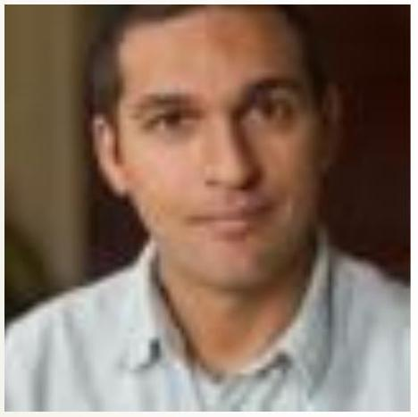

analysis and partial differential equations. In the former area, he focuses on singular integrals with modulation invariance with application, in particular, to pointwise convergence of Fourier series. His research in partial differential equations involves elliptic regularity in non-smooth domains and its application to fluid mechanics, and the asymptotic behavior of dynamical systems arising from thermoviscoelasticity.

Di Plinio has authored or co-authored 15 published research articles, the most recent of which appeared in Journal d’Analyse Mathématique (with Yumeng Ou), Journal of the London Mathematical Society (with Andrei Lerner) and Transactions of the American Mathematical Society (with Christoph Thiele). He was a Marie Curie Fellow at the University of Rome, Tor Vergata and, for the last two academic years, a Tamarkin Assistant Professor at Brown University.

Di Plinio obtained his Ph.D. in pure mathematics from Indiana University (2012). His undergraduate studies were completed at Politecnico di Milano. At the University of Virginia, he plans to help strengthen and expand the Mathematical Analysis research group, interacting with graduate and undergraduate students, as well as fellow researchers, through regular coursework and learning, research-focused seminars.

### Juraj Földes

Assistant Professor  
Department of Mathematics

Juraj Földes applies mathematical analysis to problems related to chemical reactions, composite materials, the

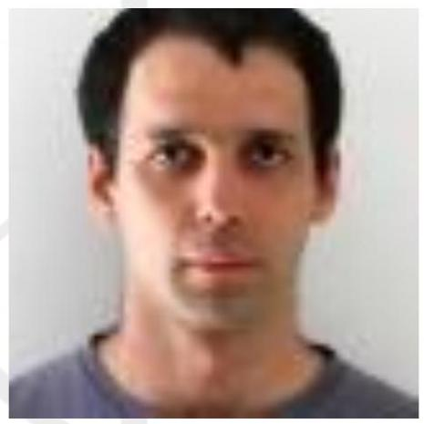

evolution of biological systems, and fluid flows. Specifically, he investigates the long-term qualitative properties of differential equations modeling turbulence in geophysical and astrophysical fluids, the evolution of colonies of bacteria, and the formation of spatial patterns and phase transitions in materials.

His work has been published in the Journal of Differential Equations, Journal of Functional Analysis, and Calculus of Variations and Partial Differential Equations. His academic honors include collaborative grants from the Mittag-Leffler Institute in Sweden, the Oberwolfach Research Institute for Mathematics in Germany, and the Banff International Research Station for Mathematical Innovation and Discovery in Canada.

After graduating with honors from the Comenius University in Slovakia, Földes earned his Ph.D. degree from the University of Minnesota (2009). He was at Vanderbilt University as a postdoctoral fellow before taking a National Science Foundation-funded postdoctoral position at the Institute for Mathematics and its Applications. Földes also held an MIS postdoctoral position at the Université libre de Bruxelles.

### Sara Maloni

Assistant Professor  
Department of Mathematics

Sara Maloni was a Tamarkin Assistant Professor at Brown

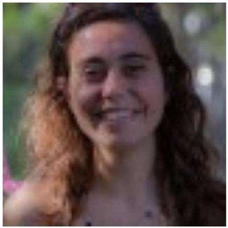

University for three years. She also spent a semester at the Mathematical Sciences Research Institute in Berkeley as a Huneke Endowed Postdoctoral Fellow. Before this, Maloni was a Postdoctoral Fellow at the University of Paris-Sud 11 and at the University of Toulouse. She has been awarded a National Science Foundation award (2015-18), and an AMS Simons Travel Grant (2014-16).

Maloni’s research lies at the intersection of geometry and low-dimensional topology. More precisely, she studies deformation spaces of geometric structures on (low-dimensional) manifolds through their geometric, topological and dynamical properties. Her published work includes papers in Groups, Geometry and Topology and Algebraic Geometry and Topology.

During her first year at UVA, she organized the Math Club, and helped to start a new AWM Student Chapter.

Maloni received her Ph.D. in Mathematics from the University of Warwick (UK) in 2013. She also received her MSc and BSc in Mathematics from University of Genova (Italy) in 2008 and 2006.

### Jennifer Morse

Professor  
Department of Mathematics

Jennifer Morse’s research lies in combinatorics and its applications to representation theory, geometry, and statistical physics. She is a world leader in symmetric functions and tableaux related combinatorics. Her discovery with Lascoux and Lapointe of $k$-Schur functions are now a central theme in this area. Her work in combinatorics related to representation theory and algebraic geometry has garnered continuous support from the National Science Foundation since 2002. She has been awarded a prestigious Simon’s Fellowship. She received the Provost’s Award for Teaching Excellence while at the University of Pennsylvania.

Morse received her PhD at the University of San Diego in 1999, and has held faculty positions at the University of Pennsylvania, the University of Miami, and Drexel University. She is a Managing Editor of the Journal of Combinatorics, and has served on numerous international scientific program committees. She brings new expertise to UVa in a rapidly expanding field.

### Axel Saenz-Rodriguez

Mary Ann Pitts Postdoctoral Fellow  
Department of Mathematics

Alex Saenz-Rodriguez research concerns integrability. He works with probabilistic models with simple interactions and the Wentzel-Kramers-Brillouin (WKB) method to approximate solutions of Painlevé equations. His research explores the interaction of geometry, representation theory, and probability.

His recent joint work includes “The Completeness of the Bethe Ansatz for the Periodic ASEP” and “Painlevé Equations, Topological Type Property and Reconstruction by the Topological Recursion.” Earlier this year, Saenz Rodriguez delivered talks and presentations at the XXXV Workshop on Geometric Methods in Physics at the University of Białystok in Poland, the Kavli Institute of Theoretical Physics at the University of California, Santa Barbara, and the $34^{\text{th}}$ annual Western States Mathematical Physics Meeting at the California Institute of Technology.

His academic honors include the GAAN Fellowship (2012-13), a Graduate Research Mentorship Fellowship (2014-15) at the University of California, Davis, and a Dissertation Year Fellowship (2015-16) at UC Davis. Saenz Rodriguez also was a graduate fellow this year at the Kavli Institute for Theoretical Physics.

Saenz-Rodriguez earned his Ph.D. in mathematics from UC Davis (2016) and his bachelor’s degree in applied mathematics from Columbia University (2011).

He is supported by a generous endowment from Robert S. Pitts (UVa, 1986) and Elizabeth O’Brien Pitts in honor of Mary Ann Pitts.

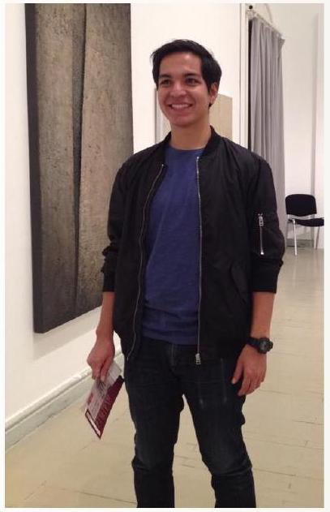

### Ramanujan Santharoubane

Whyburn Lecturer  
Department of Mathematics

Researching quantum topology and low-dimensional topology,

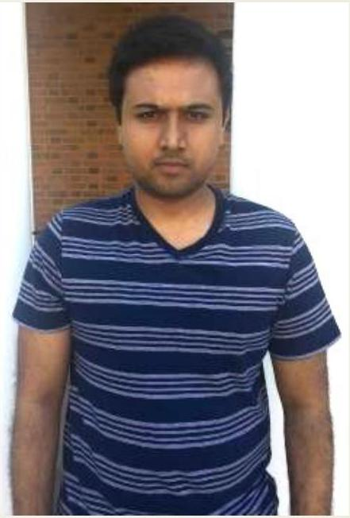

Ramanujan Santharoubane is interested in representations of mapping class groups arising from topological quantum field theories.

His Ph.D. work at Institut de Mathématiques de Jussieu – Paris, completed in 2015, concerned the so-called AMU conjecture for quantum representations of mapping class groups. In his recent work with Assistant Professor Thomas Koberda, a colleague in the Department of Mathematics, Santharoubane built representations of surface groups from topological quantum field theories. This led them to establish deep connections between quantum topology and low-dimensional topology. Their work has been published in Inventiones Mathematicae. Santharoubane’s work also has been published in the Journal of Knot Theories and its Ramifications.

Santharoubane earned his bachelor’s degree at the École Normale Supérieure of Paris (2011).

## Donald Ramirez, Professor Emeritus

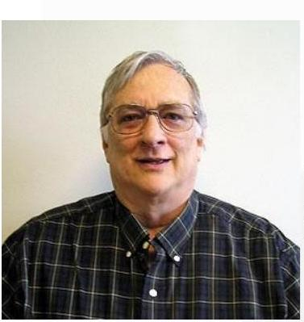

Longtime UVA Mathematics Professor Don Ramirez retired this year. He was born in New Orleans in May 1943. He attended Benjamin Franklin High School in New Orleans and was in their first graduating class in June 1960. He attended Tulane University in New Orleans graduating with a B.S. in mathematics in 1963. At Tulane, he was awarded prizes in Chemistry, Physics, Mathematics, and membership in Phi Beta Kappa. He was awarded Woodrow Wilson and NSF fellowships allowing him to continue his studies in Mathematics at Tulane, completing his PhD in May 1966. His thesis gave the solution to a conjecture of Beurling and Hewitt concerning Fourier-Stieltjes transforms, and he was awarded an Office of Naval Research Associateship at the University of Washington. There he solved a conjecture of Rudin concerning weakly almost periodic functions, and in August 1967 he became a member of the Mathematics faculty at UVA.

His service to UVA includes many years as Director of Undergraduate Programs, Associate Chairman, and Chairman in Mathematics; he has served as Chair of CEPC, was the first Director of the Statistics Forum at UVA, and held positions in the Virginia Academy of Science and the Virginia Chapter of the American Statistical Association.

After arriving at UVA in 1967, Ramirez began a long research collaboration with Charles Dunkl extending harmonic analysis results for commutative groups to non-commutative compact groups. In Transactions of Mathematical Software “Algorithm 736,” they gave an efficient procedure for computing the $n$-dimensional surface measure of an ellipsoid, extending the work of Euler (1773 for $n=2$) and Cesàro (1897 for $n=3$). His recent research has been in mathematical statistics, mostly with Donald Jensen from VPI. They introduced the generalized $F$-distribution and used it to determine single and joint outliers in complicated data sets. To handle collinear linear models, the International Encyclopedia of Statistical Science now includes the Jensen-Ramirez surrogate regression procedure as a recommended procedure. Ramirez’s current research, with José García, University of Almeria, concerns mitigating collinearity in econometric models.

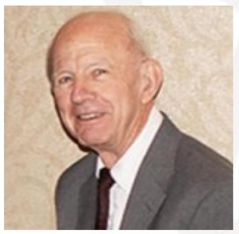

## In Memory of Eugene C. Paige, Jr., 1929–2016

Eugene C. Paige Jr, Professor Emeritus of Mathematics, passed away June 30, 2016. He received his BS in mathematics and physics from Rice University in 1950 and his PhD in mathematics from The University of Chicago in 1954 with A. Adrian Albert as his adviser. He was employed by The National Security Agency and the University of Illinois at Urbana-Champaign before coming to the University of Virginia in 1957. He was the only algebraist in the department for several years, teaching all advanced algebra classes and directing research in algebra. He had nine PhD students and many MA students. In addition to mathematics, Gene knew a lot about many things, in particular, he was very knowledgeable about digital computers and electrical engineering. In the sixties he and Marvin Rosenblum designed, built and maintained a computer network for the math department.

In the early 70’s he spent a year in Princeton, NJ at the research unit of NSA. Upon his return he was appointed Director of the Department of Institutional Analysis. He left this post to become Associate Provost of The University where one of his jobs was the oversight of Clinch Valley College, now The University of Virginia’s College at Wise. He also oversaw the development of a computer registration system for the registrar’s office. Upon Gene’s return to the mathematics department he was appointed chairman and served for three years. He retired in 1995.

Gene was eager to talk to anyone about mathematics and was always available to both students and colleagues to discuss mathematics and any other topic of interest. He was upbeat, energetic, and an extraordinary fount of practical knowledge.

## Faculty Discoveries

### John Imbrie: Exotic Quantum Systems that Fail to Equilibrate

UVA Mathematics Professor John Imbrie proved an important result confirming the existence of exotic quantum systems that fail to equilibrate. One of the fundamental principles of thermodynamics is that systems tend over time to approach a state in which all configurations are equally likely (provided they are consistent with conservation laws such as conservation of energy). For example, if all air molecules in a room are initially trapped on one side by a barrier, then after opening the barrier, the distribution of air molecules will quickly become uniform over the whole room.

Quantum systems are generally believed to equilibrate as well. But in 1958 Philip Anderson argued that a single quantum particle cannot travel freely about in a strongly disordered landscape. The quantum particle would need to tunnel between regions where the landscape is consistent with its energy, and each such tunneling event dramatically decreases the likelihood of finding the particle. This phenomenon is now called Anderson localization. His theory gave a fundamental insight into the nature of insulators, and was the basis for his Nobel Prize in 1977. Mathematical results confirming Anderson localization in three-dimensional systems were first obtained in 1983.

In recent years, physicists have conjectured that there is a many-

[figure not shown]

body version of localization for large ensembles of interacting particles. Again, in the presence of disorder, one may imagine all of the particles initially on one side of the room. Will they diffuse across the room once the barrier is removed? If the answer is no, one says that there is many-body localization or MBL. An MBL system cannot equilibrate on its own. Due to the interactions between the particles, this is a much harder question than Anderson localization. In 2006, Basko, Aleiner, and Altschuler showed to all orders in perturbation theory that localization was stable when interactions are introduced. Numerical studies by Pal, Huse, and others provided further evidence that MBL exists, at least for one-dimensional systems.

The underlying mathematical problem is one that every math major would understand: how to diagonalize a large matrix. In quantum mechanics, the states of a system are given by vectors in a Hilbert space, and the time evolution of a vector is determined by a special matrix, the Hamiltonian, $H$. The  
eigenvectors and eigenvalues of $H$ play a special role in quantum theory: they represent the stationary states of the system and their energies.

Nonperturbative effects could potentially spoil MBL – and in fact De Roeck and Huveneers recently argued that this is exactly what happens in two or more dimensions. But in one dimension, Imbrie ruled out this possibility by demonstrating in a particular model that for strong disorder all eigenstates are many-body localized. In effect, each particle comes with its own conservation law, which prevents it from straying very far from its position. His proof depends on an assumption that the spacing between eigenvalues of the Hamiltonian is not too tight – that is, there is no more than a limited amount of level attraction (or clumping) of the energy levels. This is a physically realistic assumption, since all known systems exhibit either repulsive or neutral statistics with no clumping. Thus, even though Imbrie’s work does not constitute a complete proof of MBL, it provides a very convincing case for the phenomenon.

## Faculty Awards and Honors

### Kevin McCrimmon Elected as Fellow of the American Mathematical Society

Last November, the department had the opportunity to congratulate Professor Emeritus Kevin McCrimmon on his election to the Fellows of the American Mathematical Society, class of 2017.

The AMS Fellows Selection Committee selects new Fellows based on nominations that take place at the beginning of the year. Those chosen for the prestigious position are recognized for their "outstanding contributions to the creation, exposition, advancement, communication, and utilization of mathematics."

### John Imbrie and Andrei Rapinchuk Join 2017 Simons Fellows

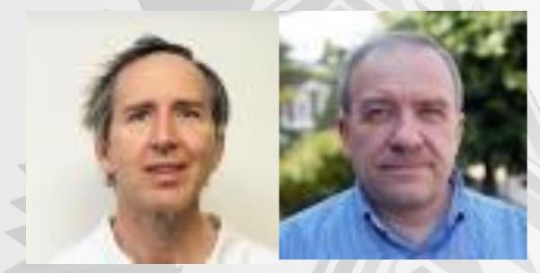

John Imbrie and Andrei Rapinchuk were selected as 2017 Simons Fellows in Mathematics. The prestigious Simons Fellows program in Mathematics provides funds to faculty for up to a semester long research leave from classroom teaching and administrative obligations.

Such leaves increase creativity and provide intellectual stimulation. The goal of the Simons Fellows Program is to make it easier to take such leaves, or to extend sabbatical leaves by an extra half year.

### Ira Herbst and Juliane Rama Awarded Annales Henri Poincaré Prize

Last fall, Professor Ira Herbst and his former postdoc, Juliane Rama, were awarded the 2015 Annales Henri

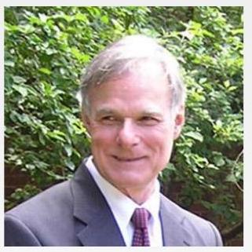

Poincaré Prize for their paper entitled "Instability of Pre-Existing Resonances Under a Small Constant Electric Field." Founded by Birkhäuser, the prize is awarded for the most remarkable paper published in the journal Annales Henri Poincaré, with winners selected by the journal’s Editorial Board. For more information, please see http://www.springer.com/birkhauser/physics/journal/23/PSE?detailsPage=societies.

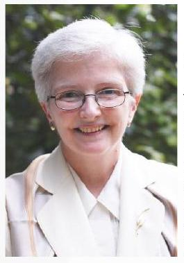

Karen Parshall Appointed Commonwealth Chair of Mathematics and History

Professor Karen Parshall has been appointed the Commonwealth Chair of Mathematics and History, an honor which was conferred last summer by the Board of Visitors. In addition, she also became the Chair of the History Department last fall. Karen came to UVa in 1988. She is an internationally known, and widely admired, historian of mathematics (especially of algebra). Her recent research includes work on the emergence of the American mathematical community. She is recognized as one of the premier mathematical historians in the world.

### Jeffrey Holt Receives Award for Excellence in Teaching

Last fall, Professor Jeffrey Holt received the 2016 Award for Excellence in Teaching. The Jefferson Scholars

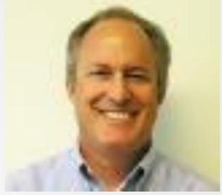

Foundation began granting the annual award in 2012 after a generous and anonymous donation. It honors those UVA faculty who demonstrate "both excellence in teaching and exceeding care for their students," and who "have gone the extra mile in fulfilling their vocation without regard for their own advancement."

### Thomas Koberda Wins 2017 Sloan Fellowship, 2017 Kamil Duszenko Award

Thomas Koberda was selected as a winner of the 2017 Sloan Research Fellowship. He is among 126 early-career scholars who represent the most promising scientific researchers working today, and whose "achievements and potential place

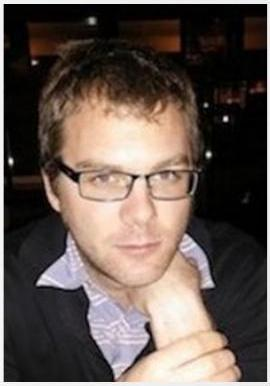

them among the next generation of scientific leaders in the U.S. and Canada. Winners receive $\$ 60,000$, which may be spent over a two-year term on any expense supportive of their research."

Thomas also won the 2017 Kamil Duszenko Award. Organized by the Wroclaw Mathematics Foundation, the Kamil Duszenko Award "is granted for outstanding work or research that has significantly contributed to the deepening of knowledge and further progress in the field of mathematics."

Thomas has been recognized for his work on low-dimensional topology and dynamics, in particular for his papers exploring connections between right-angled Artin groups and mapping class groups.

## Department Activities

### Association for Women in Mathematics

*By Sara Maloni* The Association for Women in Mathematics (AWM) is a national organization whose goal is to encourage and promote women to study and pursue careers in Mathematics.

Here at the University of Virginia, we started an AWM student chapter in the Fall of 2016. Our goals are the same: we hope to foster an inclusive and diverse environment where women and minorities feel welcome and encouraged. In our efforts to increase the number of women and underrepresented minorities pursuing a career in these fields, while also increasing retention levels, we organize programs and events that are open to everyone in the UVa community (see the webpage http://people.virginia.edu/~er2eq/uva-awm/home.html for a full list of activities). In February 2017 we received a $6,000 Diversity and Inclusion Grant, and the departments of Mathematics, Physics and Statistics promised up to $1,500, $1,000, and $1,000 respectively in matching funds. Most of the female graduate students and a few male students are active members of the organizational board.

Some of the activities we organized include: starting a mentoring program involving faculty, graduate students and undergraduate students; working with Colloquium and Seminar organizers in order to increase the number of female speakers and so promote the visibility of successful women, organizing lunches with such female speakers; and organizing a "hosting program" for prospective students, pairing them with a local graduate student. In order to recruit and retain women and minorities at all levels, we also coordinated some social activities, including a visit to the art exhibition of Dorothea Rockburne, ice skating, and a celebration of Pi Day with pies. We also partnered with the Math Club to organize a panel discussion on REU and other research opportunities for undergraduate students, and another on jobs for math majors inside and outside academia.

Next year we plan to organize a public lecture dedicated to discussing issues related to promoting diversity and bias in Science and a series of public lectures entitled "Math and ..." joint with other departments.

[figure not shown]

"Dorothea Rockburne: In My Mind’s Eye" Installation photo courtesy of the Parrish Art Museum.

### Math Majors of America Tournament for High Schools

This year, our department had the opportunity to be involved in the Math Majors of America Tournament for High Schools. According to the organization’s website, the goal of the tournament is "to assist universities in hosting their own math tournaments for schools within their state or region; provide a team-based competition that is accessible, both physically and mathematically, to more high school students; and promote communication between undergraduate students in mathematics across the country."

The volunteers take on a number of tasks, such as "submitting questions, editing the tests, or volunteering on the day of the contest." According to Muthu Chidambaram, Co-Chair of the Virginia Math Society, this year’s contest consisted of 11 teams of 6 high school students each competing in a team round, an individual round, and a mixer round in which students from different teams were matched together.

"Overall," Muthu concludes, "it seemed like both the volunteers and the high school students had a great time, so hopefully we’ll be able to expand the contest in the years to come." To learn more about the tournament, visit: http://www.mmaths.org/.

## Virginia Mathematics Lecture Series

In 2014, the IMS established the Distinguished Lecture Series "Virginia Mathematics Lectures." This year, James Arthur (University of Toronto) delivered a series of lectures in the Fall: "$L$-functions and Number Theory," "The Trace Formula and Automorphic Forms," and "Beyond Endoscopy and Functoriality." In the Spring, Benedict Gross (Harvard) presented three lectures: "The Rank of Elliptic Curves," "The Arithmetic of Hyperelliptic Curves," and "Heegner Points on Modular Curves." These were given to an enthusiastic audience which included undergraduate and graduate students, faculty members, and guests from other departments and institutions.

### Spotlight: Benedict Gross

On March 24–29, 2017, the Department of Mathematics and the IMS hosted a two-part event that began with the workshop "Elliptic Curves, Torsors and $L$-functions" followed by the three lectures by Benedict H. Gross in our Distinguished Lecture Series "Virginia Mathematics Lectures." The subject of Gross’s lectures was the arithmetic of elliptic and hyperelliptic curves, the ranks of elliptic curves in the light of the famous conjecture of Birch and Swinnerton-Dyer as well as the recent results (due to the Fields medalist M. Bhargava, B.H. Gross, B. Poonen, …) in the new area of "arithmetic statistics" that studies the average rank of elliptic curves over the rationals, the average number of rational points on classes of curves and similar issues. The lectures and short communications in the workshop complemented Gross’s lectures by expanding into related areas of arithmetic geometry and the arithmetic theory of algebraic groups. The speakers in the workshop came from many universities in the US (including Harvard, Princeton, Emory, Michigan, UCLA) and other countries. Gross’s research focuses on number theory and related representation theory. He has made fundamental contributions to various aspects of the subject, particularly his work on elliptic curves, which served as the subject of this lecture series. Within this sub-discipline, his Inventiones paper with Don Zagier was the first major breakthrough on the famous Birch and Swinnerton-Dyer conjecture, which gives an amazing insight into the connections between algebra and number theory on the one hand, and analysis on the other (more precisely, between the rational points on an elliptic curve and the analytic properties of its $L$-function). He is a recipient of numerous prestigious awards, including the Marshall Scholarship (1972–74), Sloan Fellowship (1980–83), and the AMS Cole Prize in number theory (1987). In 2004, he became a member of the National Academy of Sciences.

[figure not shown]

## Gordon E. Keller Mathematics Majors Dinner

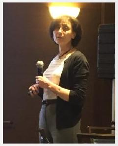

Raina Robeva

### E. J. McShane Prize in Mathematics, April 2017

The 2017 E. J. McShane Prize in Mathematics was given to Peter Dillery and Bradley Zykoski for their achievements in mathematics.

### William Lowell Putnam Mathematical Competition Award, April 2017

The 2017 William Lowell Putnam Mathematical Competition Award was given to Collin Berman and Alec Zhang for their outstanding scores on the exam. Congratulations!

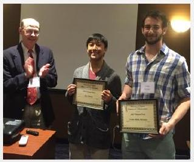

Huneke, Zhang, and Berman

[figure not shown]

Zykoski, Gromoll, and Dillery

### Speaker: Dr. Raina Robeva

The 2017 Gordon E. Keller Mathematics Majors Dinner, supported by a generous gift by Doug and Laurel Costa, took place last Spring. This year featured Dr. Raina Robeva as our guest speaker, who lectured about mathematical biology. Dr. Robeva received her PhD in Mathematics from the University of Virginia in 1997 and currently holds the position of Professor of Mathematical Sciences at Sweet Briar College. The breadth of her research includes systems biology, random processes and fields, and mathematical modeling for biology and the biomedical sciences. The National Science Foundation and the National Institutes of Health are among those who fund her research. Three U.S. patents for assessment and diagnosis of attentional impairments were the direct result of her translational research. In 2014, Robeva received the Outstanding Faculty Award of the State Council of Higher Education for Virginia.

### Five Majors Elected into Phi Beta Kappa

Congratulations to: Olivia Hughes Bicks, Peter Emil Dillery, Ji Won Kim, Dan Yu, and Yutong Zhang! As the oldest and most distinguished honor society in the country, Phi Beta Kappa offers membership to less than one percent of all undergraduates. Many of the leading figures in American history and culture have begun their careers with election to the society, including seventeen presidents of the United States. As a result, membership is a remarkable accomplishment, both for the student who achieves it and the faculty and staff whose support and guidance has led to this milestone.

## Recent PhDs

### Peter Bonventre [Advisor: Michael Hill]

Comparison of models for equivariant operads Peter will be going to the University of Kentucky as a postdoctoral appointment.

### Katelynn Kochalski [Advisor: Christian Gromoll]

Fluid limits and the batched processor sharing model Katie has accepted a tenure-track job at SUNY Cortland.

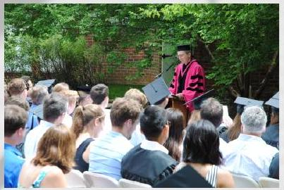

John Imbrie Addresses the Graduates

### Hankyung Ko [Advisor: Brian Parshall]

Representations of quantum groups at roots of unity and their reductions mod $p$ to algebraic group representations  
Hankyung is currently working as a visitor of the Max Planck Institute for Mathematics in Bonn, Germany.

### Keith Leitmeyer [Advisor: Zoran Grujic]

Turbulence, regularity, and geometry in solutions to the Navier-Stokes and magnetohydrodynamic equations

### Bo Wang [Advisor: Christian Gromoll]

A generalization of martingale theory to self-averaging processes

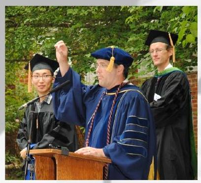

Bo has accepted a position as a quantitative research analyst for Susquehanna International Group in Philadelphia.

### Michael Willis [Advisor: Slava Krushkal]

Stable Limits of the Khovanov Homology and L-S-K Spectra for Infinite Braids  
Mike will be going to UCLA on a postdoctoral appointment.

### Xiang Wan [Advisor: Irena Lasiecka]

Global Existence and Exponential Stability for a Nonlinear Thermoelastic Kirchhoff-Love Plate System

### Anthony Mak [Advisor: Thomas Mark]

Towards an Alternative Notion of General Type Symplectic $4$-Manifolds

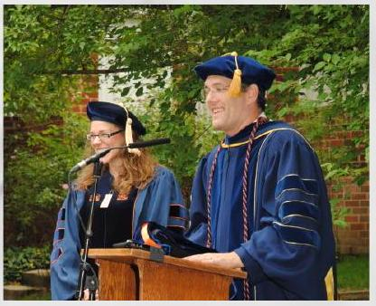

PhD Recipient Katie Kochalski with Christian Gromoll

## Graduate Awards and Honors

### Xiang Wan Wins Third Place at 3MT Competition

Congratulations to Xiang Wan, who won third place in this year’s 3MT (three-minute thesis) competition! This academic competition challenges Ph.D. students to describe their research within three minutes to a general audience. 3MT celebrates the discoveries made by research students and

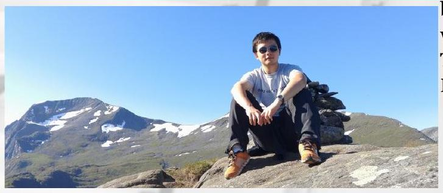

encourages them to communicate the importance of their research to the broader community. Xiang Wan’s thesis was entitled "A Mathematical Treatment of Heating and Bending."

### Congratulations to Our Graduate Teaching Award Winners!

2016-17 Department of Mathematics Outstanding Graduate Teaching Assistant Award:

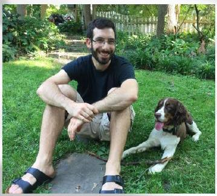

Peter Bonventre

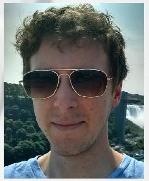

Jonathan Simone

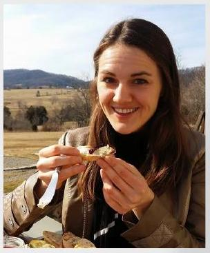

2016-17 All-University Graduate Teaching Award:

Kristin Courtney

## Leonid Petrov: Random Tilings

Random tilings (by rhombi of 3 types) model 3-dimensional interfaces in melted crystals and related models of statistical mechanics. A tiling is drawn uniformly at random from the collection of all possible tilings of, say, a given large polygon. There are exponentially many possible tilings, and yet a typical uniformly random tiling does not look completely random. In particular, close to each vertex of the polygon a single type of rhombi prevails, and one clearly sees a curve (a cardioid for this particular polygon) separating these "frozen" regions from the central region containing a random mix of rhombi.

UVa Assistant Professor Leonid Petrov analyses asymptotic behavior of random tilings as the size of the polygon goes to infinity, and in particular studies how nonrandom limit shapes arise from boundary conditions. He also implements code generating large random tilings pictures like this one. In Fall 2016 two of his pictures in collaboration with Alexei Borodin from MIT were included in a science art exhibition at the Radcliffe Institute for Advanced Study at Harvard.

[figure not shown]

## The Problem Corner

1. Prove that every positive integer has a multiple whose decimal representation involves the sequence 20162017.
2. A region of the plane is said to be convex if the chord joining any two of its points lies inside the region. A region $R$ is star-shaped if there is a point $C$ in $R$, called a central point of $R$, such that for each point $P$ in $R$, the chord joining $C$ to $P$ lies inside $R$. Prove that if $R$ is star-shaped, then the set of all its central points $C$ is convex.
3. The possible scores in the game of tossing two dice are the integers $2,3, \ldots, 12$.

   Is it possible to assign probabilities to each of the six sides of the two dice (the dice do not need to have the same assigned probabilities) in such a way that these eleven outcomes are equally likely?
4. Show that the sum of $1/kj$, where $k$ and $j$ are relatively prime integers between $1$ and $n$, and $k+j \geq n+1$, is equal to $1$. (Note each pair $k, j$ is counted twice since you may reverse them. For example, when $n=3$, $1/1\cdot 3+1/3\cdot 1+1/2\cdot 3+ 1/3\cdot 2=1$.)

## What are you Doing?

We’d like to hear from you!  
You may complete the form below and return it to us: Form [ctrl+click]: http://pi.math.virginia.edu/questionnaire.pdf  
Facebook:[Ctrl+click].https://www.facebook.com/UVAMath

FAX: 434-982-3084  
Email: math-help@virginia.edu  
Department of Mathematics  
University of Virginia  
P. O. Box 400137

Charlottesville, VA 22904-4137